# Competition 2 readme

#### Average and sum score curve

The paths of average scores are non linear. They do not appear to fit the fixed effect model well in the biootom part of a sample.

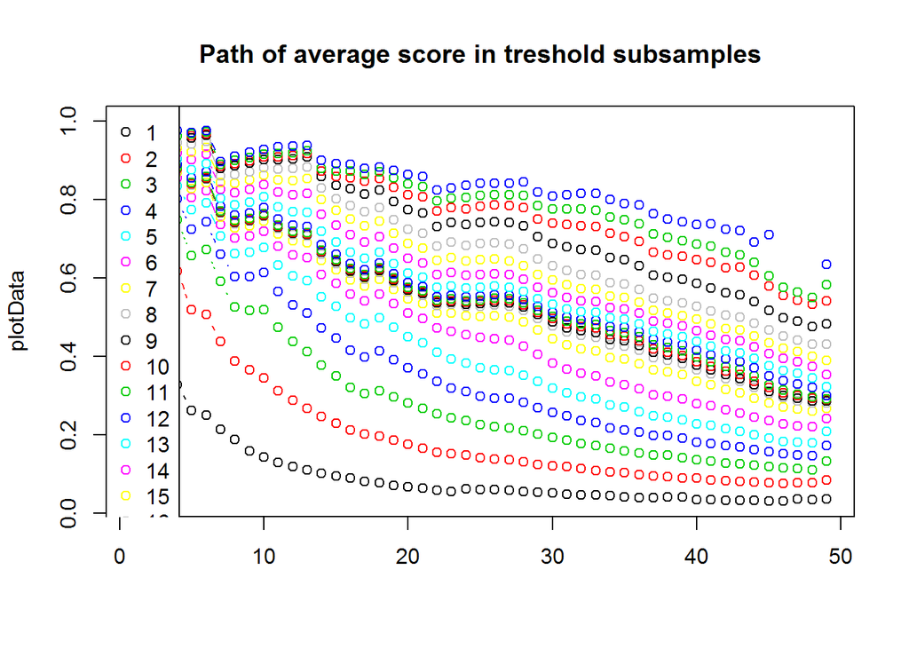

On the below plot we can observe so called “glass ceilling effect”. As the difficulty increases with each question, it is highly unlikely for an unskilled individual to answer later question. This results in relatively flat sum of scores- the sum of scores is not increasing with additional questions.

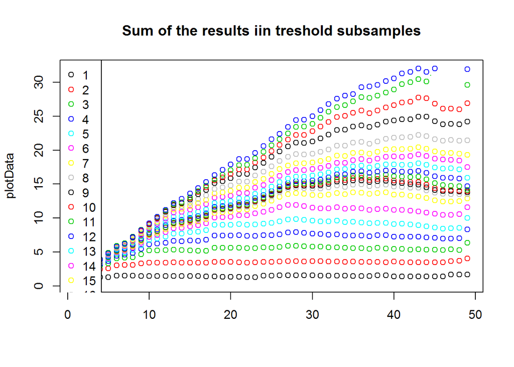